# 11 Bad UX

App Prototyping Studio

Mick McQuaid

mcq@utexas.edu

University of Texas at Austin

03 Nov 2026

# Week ELEVEN

# Popularization via bad design

Norman (2013) popularized the identification of bad design in its first edition in the eighties.

## Why spend two days on it anyway?

- Noticing bad design is cheap. Everyone in this room can do it already.
- Diagnosing it precisely is a skill. Most people can’t.
- Fixing it at a cost someone will pay is the job. Almost nobody does this without practice.
- Your assignment is graded on the last two, not the first. This week is practice.
- And your beta reports just came in. Some of the bad UX we look at this week is yours.

## Vocabulary

- **Affordance.** A relationship between a thing and a person: what the thing lets that person do. A handle affords grasping. A flat plate affords pushing.
- **Signifier.** Any perceivable cue that tells you where to act and how. The word “Push.” The shape of the plate. Norman added this word in 2013 because people kept using “affordance” to mean it.
- **Mapping.** The relationship between controls and their effects. Four burners, four knobs, which is which?

## More vocabulary

- **Feedback.** Something that tells you the action happened. The click, the light, the spinner.
- **Conceptual model.** The story in your head about how the thing works. Usually simplified, often wrong, built from the signifiers you can see.
- **Constraints.** Physical, cultural, semantic, and logical limits on what you can do. The USB-A plug that only fits one way after three tries.

## The two gulfs

- **Gulf of execution.** I know what I want. How do I do it with this thing?
- **Gulf of evaluation.** I did something. What happened? Did it work?
- Every example you photographed sits on one side or the other.
- Pictures are good at showing the gulf of execution. The confused hand on the handle is a photograph.
- Pictures are bad at showing the gulf of evaluation. “Nothing happened” doesn’t photograph.
- Keep this in mind on Thursday. Your prototype’s worst failures are probably the ones you can’t photograph.

## When the sign goes up, the design has failed

- Norman: when simple things need pictures, labels, or instructions, the design has failed.
- Every taped-on sign is a confession. Someone watched users fail and reached for a label instead of a redesign.
- The sign is also evidence. It tells you exactly where the gulf is, because somebody had to stand there and watch.
- Apps have stickers too: tooltips, coach marks, onboarding tours, “tap here to get started,” a help icon next to a field.
- Not every sticker is wrong. But every sticker is a place you should have considered a redesign first.

## Human error is design error

- When people fail with a thing, they blame themselves. “I’m so stupid, I pushed the pull door.”
- Norman’s chapter five argues that this is backwards. The design put a competent person in a position to fail.
- Reason (1990) made the same argument about industrial accidents. The operator is the last link, not the cause.
- Design consequence: when a tester fails your prototype, the finding is about your prototype.
- You already know this from your beta reports. Reread your findings with this in mind: how many times did you write “the participant didn’t notice”?

## Why competent people ship bad design

# Worked examples

## The diagnosis template

- **Expected.** What did the design lead the user to expect?
- **Actual.** What actually happened?
- **Property.** Which property of the design produced the gap? Name it with a word from the vocabulary slide (or the more vocabulary slide).
- **Fix.** Redesign, not complaint. Show it.
- **Cost.** What does the fix cost? Manufacturing, screen space, a tap, retraining, revenue.
- Every example that follows gets run through this template. So does yours.

# Exercise 1: Cold read

## Rules

- Seven pictures follow. No titles, no explanation, forty-five seconds each.
- For each one, write three lines: expected, actual, property. Use a word from the vocabulary slide for the property.
- If you can’t find the problem in forty-five seconds, write “can’t see it.” That is a finding about the picture, not about you.
- Pair up. After the seventh picture, compare answers with your partner. Where you disagree about the property, argue until one of you changes.
- Then I show the same pictures again with my diagnosis. Score yourself: same property or different?

## 1

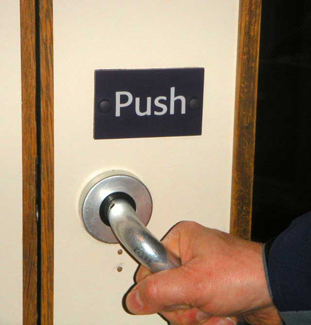

## 2

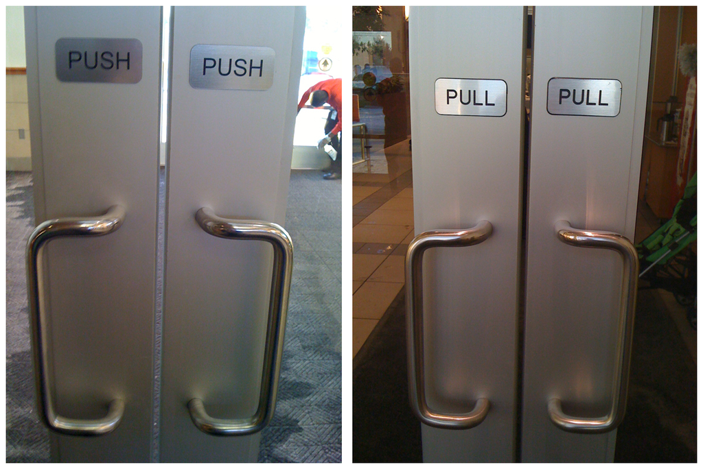

## 3

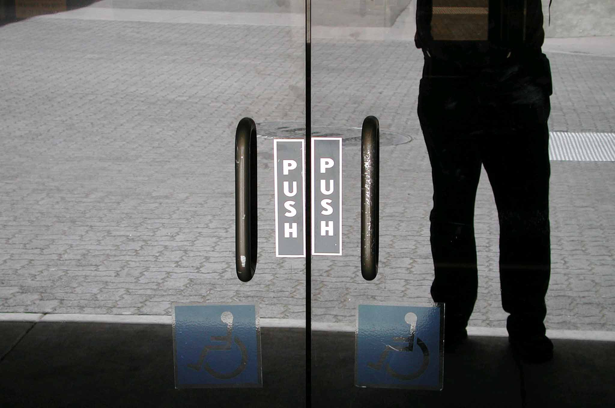

## 4

[figure not shown]

## 5

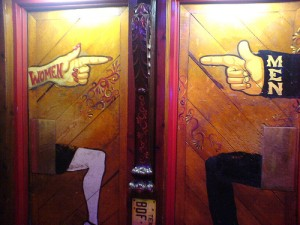

## 6

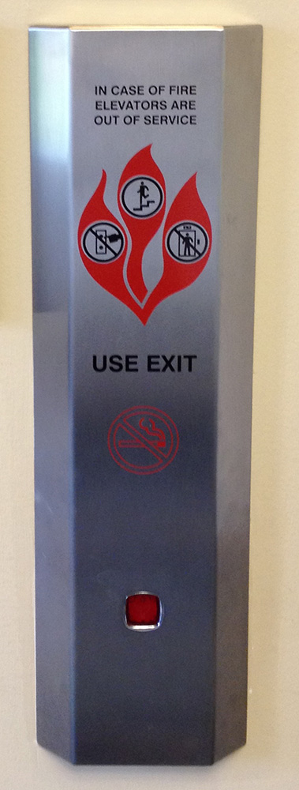

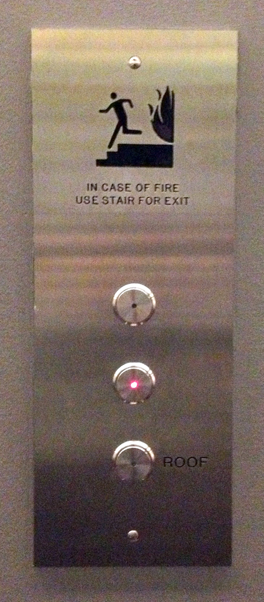

## 7

[figure not shown]

## Compare

- With your partner: same property on how many of seven?
- Which picture produced the most disagreement in the room? That’s the one worth talking about.
- Which picture did the most people mark “can’t see it”? That picture fails the assignment, even though the design it shows is bad.
- Now the reveal.

# Worked examples

## Flat design risks

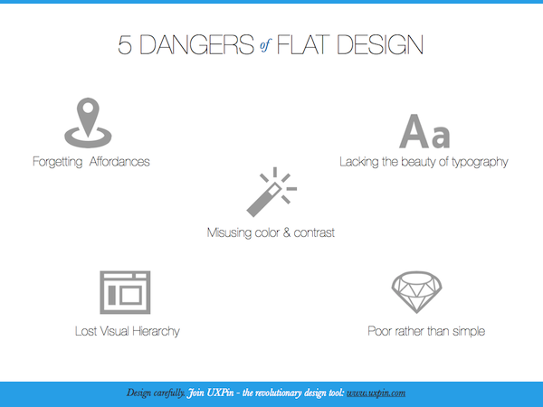

## Bad door

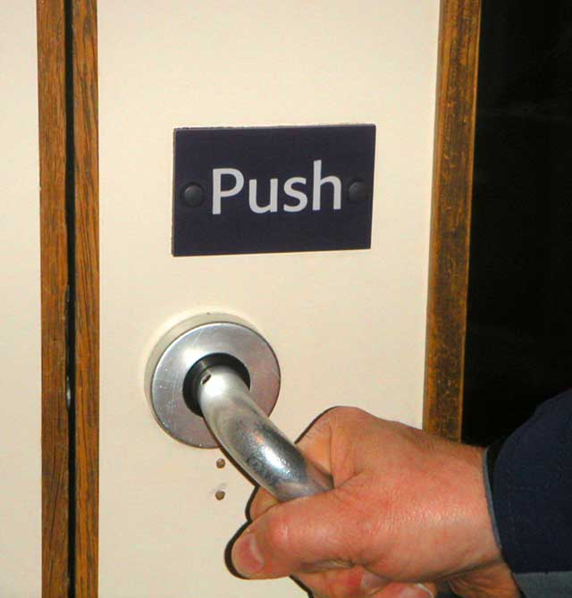

## Bad and less bad door

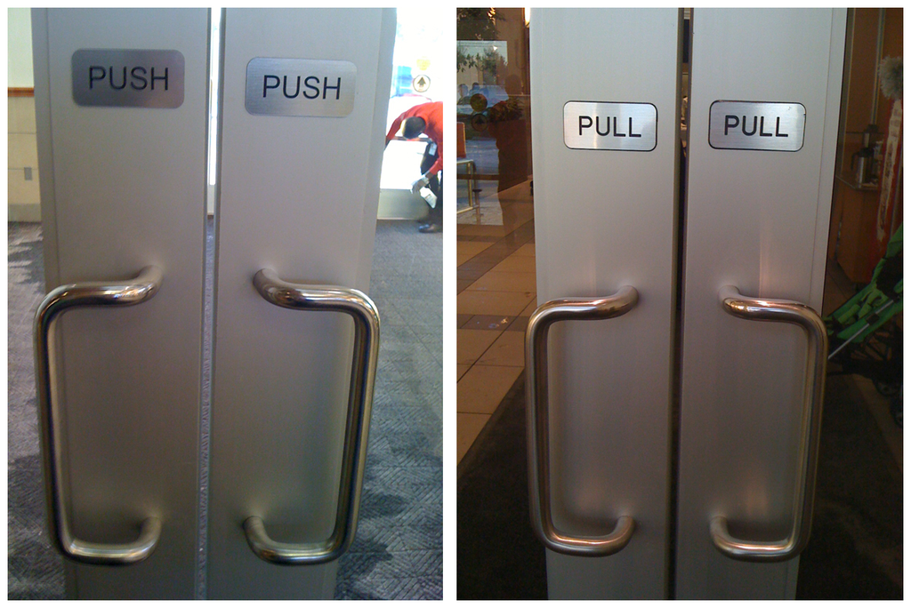

## Anti-ADA door

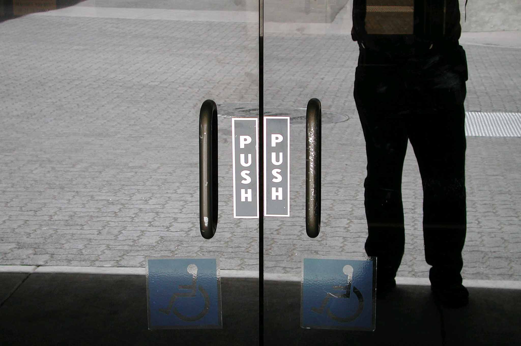

## Bad dryer

[figure not shown]

## Bad iPad

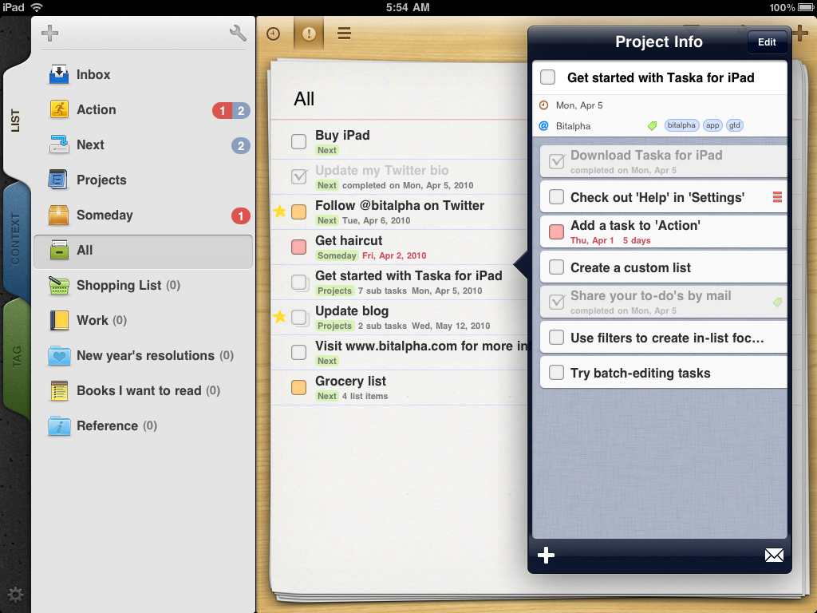

## Bad iPad’s ancestor

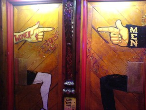

## Bad elevators

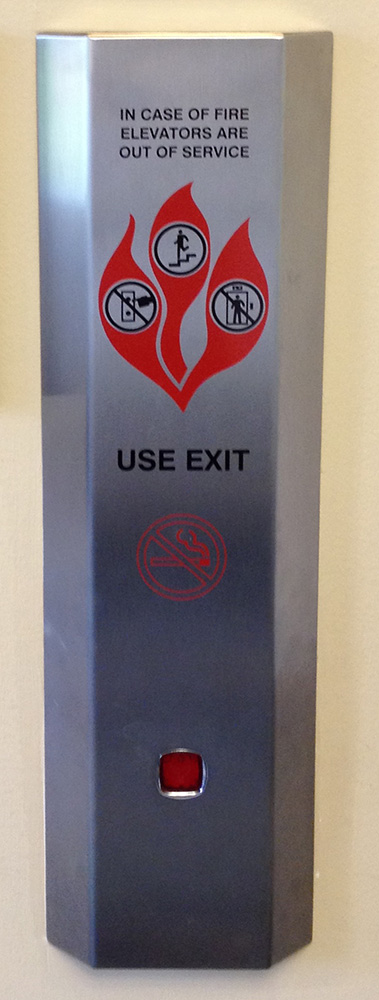

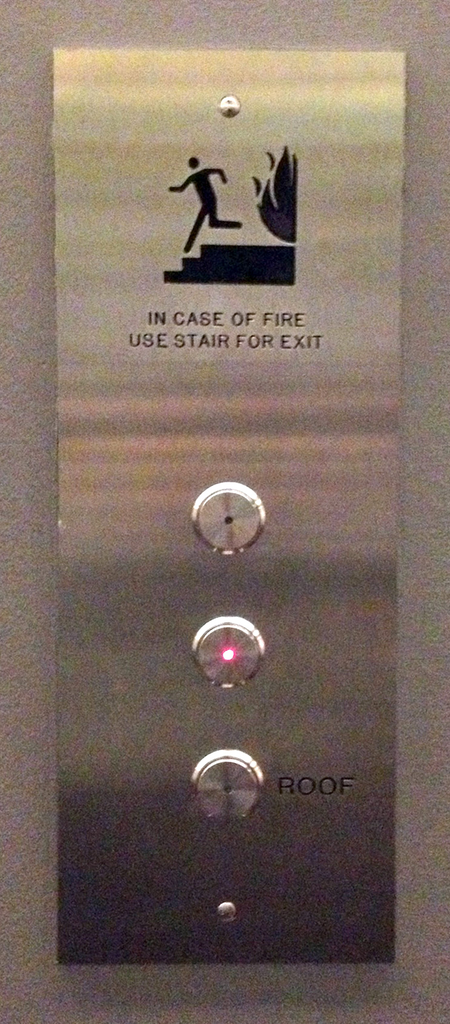

## Hotel showers

[figure not shown]

# The same failures on a screen

## Translate the doors into your prototype

- **Norman door.** A card that looks tappable and isn’t. Text that looks like a link and isn’t. A button that looks disabled and isn’t.
- **Dryer door.** The dialog that opens on top of the information you need to fill it in. The keyboard that covers the field you’re typing into. The layout was set before anyone knew what would be next to it.
- **Unlabeled elevator.** An icon-only toolbar. Five icons, no words, and one of them deletes.
- **Rubik’s shower.** Anything you must operate fast, under penalty, with no signifier for how. The alarm you can’t silence at 5 a.m. The car’s touchscreen climate control at highway speed. The payment terminal with a line behind you. Experts fly through it; everyone else gets burned.
- **Mystery red button.** A destructive action with no label and no undo.
- **Taped-on sign.** An onboarding tour that explains the navigation.

## Failures that don’t photograph

- **Feedback.** You tapped “order” and nothing happened, so you tapped again. Two orders.
- **State.** Is it saved? Is it syncing? Which account am I in?
- **Mode.** Caps lock. Edit mode. The same tap does something different and nothing tells you which mode you’re in.
- **Time.** The spinner that never ends. The confirmation that arrives after you gave up.
- **Absence.** The cancel path that was never designed because nobody drew the unhappy path.
- These are most of what real usability failures look like, and almost none of your photos show them. That’s a limitation of the assignment, not of the failures.